[figure not shown]

EN(STI)(diag)-67

Diagnostics for Engine Starting Failure

ENGINE (DIAGNOSTICS)

16.Diagnostics for Engine Starting Failure

A: PROCEDURE

1. Check of the fuel amount

↓

2. Inspection of starter motor circuit <Ref. to EN(STI)(diag)-68, STARTER MOTOR CIRCUIT, Diagnostics for Engine Starting Fail-

ure.>

↓

3. Inspection of ECM power supply and ground line <Ref. to EN(STI)(diag)-77, CHECK POWER SUPPLY AND GROUND LINE

OF ENGINE CONTROL MODULE (ECM), Diagnostics for Engine Starting Failure.>

↓

4. Inspection of ignition control system <Ref. to EN(STI)(diag)-79, IGNITION CONTROL SYSTEM, Diagnostics for Engine Start-

ing Failure.>

↓

5. Inspection of fuel pump circuit <Ref. to EN(STI)(diag)-81, FUEL PUMP CIRCUIT, Diagnostics for Engine Starting Failure.>

↓

6. Inspection of fuel injector circuit <Ref. to EN(STI)(diag)-82, FUEL INJECTOR CIRCUIT, Diagnostics for Engine Starting Fail-

ure.>

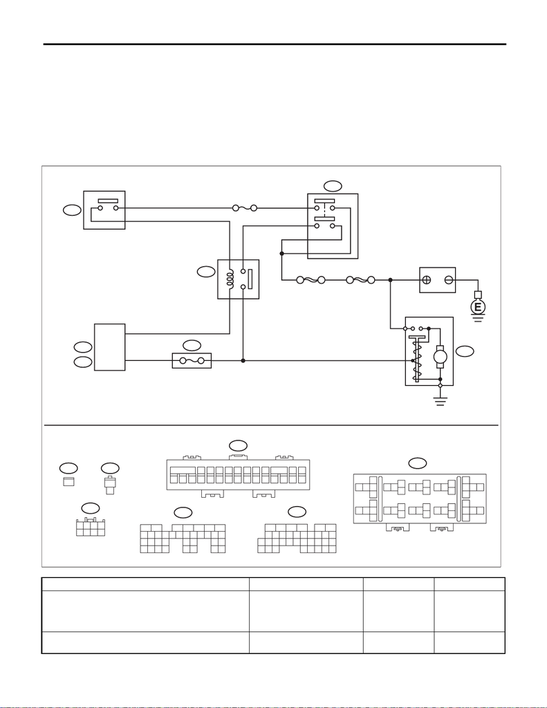

EN(STI)(diag)-68

Diagnostics for Engine Starting Failure

ENGINE (DIAGNOSTICS)

B: STARTER MOTOR CIRCUIT

1. MODEL WITHOUT PUSH BUTTON START

CAUTION:

After servicing or replacing faulty parts, perform Clear Memory Mode <Ref. to EN(STI)(diag)-59, OP-

ERATION, Clear Memory Mode.>, and Inspection Mode <Ref. to EN(STI)(diag)-43, PROCEDURE, In-

spection Mode.>.

WIRING DIAGRAM:

Engine Electrical System ENGINE TYPE EJ (WITHOUT PUSH BUTTON START) <Ref. to WI-198, ENGINE

TYPE EJ (WITHOUT PUSH BUTTON START), WIRING DIAGRAM, Engine Electrical System.>

Step Check Yes No

1 CHECK BATTERY.

Check the battery. <Ref. to SC(STI)-21,

INSPECTION, Battery.>

Is the battery OK? Go to step 2. Charge or replace

the battery. <Ref.

to SC(STI)-21,

Battery.>

2 CHECK OPERATION OF STARTER MOTOR. Does the starter motor oper-

ate?

Go to step 3. Go to step 4.

B72

7856

3412

22 8

B550

1

3

2

B225

5

B14

1

B106

1

M

7

B72

B136C:

B135B:

B14

1

B106

1

2

B225

10 11

12

13

14 15

16

18

19 21 22

20

17

24

5

3

17

9

8

6

32 33

34

35

28262423

25

27

29

30

31

36 37

38

40

41 43 44

42

39

2524

30

987

17 18 19 20

28

21 22 23

29

3231

1234

56

2726

33 34 35

B136C:

B135B:

567

8

21

9

43

10

2422 23 25

11 12 13 14 15

26 27

28

16 17 18 19

20 21

29 30 31 32 33 34 35

EN-10851

3

4

5

2

B26

C16

101

5

14

13

18

432

17

7

16

698

15

11 12

B550

SBF-6

ECM

BATTERY

IGNITION SWITCH

F/B No. 21

MAIN SBF

CLUTCH START

SWITCH

STARTER MOTOR

STARTER

RELAY

FUSE HOLDER

[figure not shown]

EN(STI)(diag)-69

Diagnostics for Engine Starting Failure

ENGINE (DIAGNOSTICS)

3 CHECK DTC. Is DTC displayed? <Ref. to

EN(STI)(diag)-42, OPERA-

TION, Read Diagnostic Trouble

Code (DTC).>

Check the appro-

priate DTC using

the “List of Diag-

nostic Trouble

Code (DTC)”.

<Ref. to

EN(STI)(diag)-86,

List of Diagnostic

Trouble Code

(DTC).>

Check ignition con-

trol system. <Ref.

to EN(STI)(diag)-

79, IGNITION

CONTROL SYS-

TEM, Diagnostics

for Engine Starting

Failure.>

4 CHECK INPUT SIGNAL FOR STARTER MO-

TOR.

1) Turn the ignition switch to OFF.

2) Disconnect the connector from starter

motor.

3) Depress the clutch pedal.

4) Turn the ignition switch to START.

5) Measure the voltage between the starter

motor connector and the engine ground.

Connector & terminal

(B14) No. 1 (+) — Engine ground (–):

Is the voltage 10 V or more? Check the starter

motor. <Ref. to

SC(STI)-7,

Starter.>

Go to step 5.

5 CHECK INPUT SIGNAL FOR STARTER MO-

TOR.

1) Depress the clutch pedal.

2) Turn the ignition switch to START.

3) Measure the voltage between starter relay

connector and chassis ground.

Connector & terminal

(B225) No. 1 (+) — Chassis ground (–):

Is the voltage 10 V or more? Repair the open

circuit of the har-

ness between

starter relay con-

nector and starter

motor.

Go to step 6.

6 CHECK HARNESS BETWEEN BATTERY

AND IGNITION SWITCH CONNECTOR.

1) Turn the ignition switch to OFF.

2) Disconnect the connector from ignition

switch.

3) Measure the voltage between ignition

switch connector and chassis ground.

Connector & terminal

(B72) No. 4 (+) — Chassis ground (–):

(B72) No. 5 (+) — Chassis ground (–):

Is the voltage 10 V or more? Go to step 7. Repair the power

supply circuit.

7 CHECK IGNITION SWITCH.

Measure the resistance between ignition switch

terminals after turning the ignition switch to

START position.

Terminals

No. 3 — No. 4:

No. 5 — No. 7:

Is the resistance less than 1 Ω? Go to step 8. Replace the igni-

tion switch. <Ref.

to SL-64,

REPLACEMENT,

Ignition Key Lock.>

8 CHECK INPUT VOLTAGE OF CLUTCH

START SWITCH.

1) Turn the ignition switch to OFF.

2) Disconnect the connector from clutch start

switch.

3) Connect the connector to ignition switch.

4) Turn the ignition switch to START.

5) Measure the voltage between the clutch

start switch connector and chassis ground.

Connector & terminal

(B106) No. 1 (+) — Chassis ground (–):

Is the voltage 10 V or more? Go to step 9. Check the follow-

ing item and repair

if necessary.

• Blown out of fuse

(F/B No. 21)

• Open or short

circuit to ground in

harness between

ignition switch con-

nector and clutch

start switch con-

nector

Step Check Yes No

[figure not shown]

EN(STI)(diag)-70

Diagnostics for Engine Starting Failure

ENGINE (DIAGNOSTICS)

9 CHECK HARNESS BETWEEN STARTER RE-

LAY CONNECTOR AND CLUTCH START

SWITCH CONNECTOR.

1) Turn the ignition switch to OFF.

2) Remove the starter relay.

3) Measure the resistance of harness between

starter relay connector and clutch start switch

connector.

Connector & terminal

(B225) No. 3 — (B106) No. 2:

Is the resistance less than 1 Ω? Go to step 10. Repair the open

circuit in harness

between starter

relay connector

and clutch start

switch connector.

10 CHECK INPUT VOLTAGE OF STARTER RE-

LAY.

1) Connect the connector to the clutch start

switch.

2) Depress the clutch pedal.

3) Turn the ignition switch to START.

4) Measure the voltage between starter relay

connector and chassis ground.

Connector & terminal

(B225) No. 3 (+) — Chassis ground (–):

Is the voltage 10 V or more? Go to step 11. Replace the clutch

start switch. <Ref.

to CL-35, Clutch

Switch.>

11 CHECK INPUT VOLTAGE OF STARTER RE-

LAY.

1) Turn the ignition switch to START.

2) Measure the voltage between starter relay

connector and chassis ground.

Connector & terminal

(B225) No. 2 (+) — Chassis ground (–):

Is the voltage 10 V or more? Go to step 12. Repair the open

circuit of harness

between starter

relay connector

and ignition switch

connector.

12 CHECK STARTER RELAY.

1) Connect the battery to starter relay termi-

nals No. 3 and No. 5.

2) Measure the resistance between starter

relay terminals.

Terminals

No. 1 — No. 2:

Is the resistance less than 1 Ω? Go to step 13. Replace the starter

relay.

13 CHECK HARNESS BETWEEN ECM AND

STARTER RELAY CONNECTOR.

1) Turn the ignition switch to OFF.

2) Disconnect the connector from ECM.

3) Measure the resistance of harness between

ECM connector and starter relay connector.

Is the resistance less than 1 Ω? Go to step 14. Repair the harness

and connector.

NOTE:

In this case, repair

the following item:

• Open circuit of

harness between

ECM connector

and starter relay

connector

• Blown out of fuse

14 CHECK ECM INPUT VOLTAGE.

1) Install the starter relay.

2) Depress the clutch pedal.

3) Turn the ignition switch to START.

4) Measure the voltage between ECM connec-

tor and chassis ground.

Connector & terminal

(B135) No. 26 (+) — Chassis ground (–):

Is the voltage 10 V or more? Check the ECM

power supply and

ground line. <Ref.

to EN(STI)(diag)-

77, CHECK

POWER SUPPLY

AND GROUND

LINE OF ENGINE

CONTROL MOD-

ULE (ECM), Diag-

nostics for Engine

Starting Failure.>

Repair the open

circuit of harness

between ECM con-

nector and starter

relay connector.

Step Check Yes No

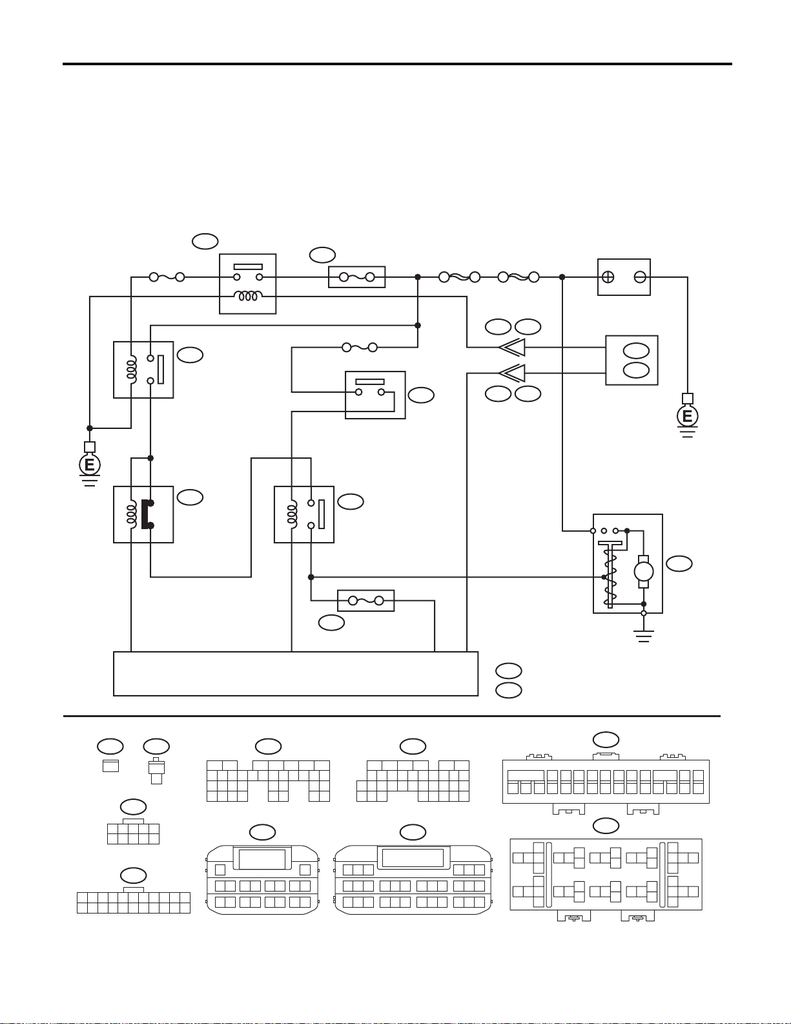

EN(STI)(diag)-71

Diagnostics for Engine Starting Failure

ENGINE (DIAGNOSTICS)

2. MODEL WITH PUSH BUTTON START

CAUTION:

After servicing or replacing faulty parts, perform Clear Memory Mode <Ref. to EN(STI)(diag)-59, OP-

ERATION, Clear Memory Mode.>, and Inspection Mode <Ref. to EN(STI)(diag)-43, PROCEDURE, In-

spection Mode.>.

WIRING DIAGRAM:

Engine Electrical System ENGINE TYPE EJ (WITH PUSH BUTTON START) <Ref. to WI-218, ENGINE

TYPE EJ (WITH PUSH BUTTON START), WIRING DIAGRAM, Engine Electrical System.>

ECM

B23

12345

6789

10

B550

228

B136C:

B135B:

B14

1

M

B574C:

B572A:

B28B23

3

21

A7

C6

1

B106

1

3

2

B225

5

28

30

29

B225

31

39 38

36 37

B225

789

10 11 12 13 14 15 16 17 18

123 456

B574C:

11 12

34

13 14

56

15 16

78

17 18

10

9

12

B572A:

1610 11 12 13 14 15

2524

30

987

17 18 19 20

28

21 22 23

29

3231

1234

56

2726

33 34 35

B136C:

567

8

21

9

43

10

2422 23 25

11 12 13 14 15

26 27

28

16 17 18 19

20 21

29 30 31 32 33 34 35

B135B:

B575

123

456789

10 11

B225

10 11

12

13

14 15

16

18

19 21 22

20

17

24

5

3

17

9

8

6

32 33

34

35

28262423

25

27

29

30

31

36 37

38

40

41 43 44

42

39

B106

1

2

EN-10852

B14

1

B550

1024

41

42

44

B225

40

2

B34

B26

C16

C27

B576B575

101

242322 272625212019

5

14

13

18

432

17

7

16

698

15

11 12

B550

SBF-6

STARTER CUT

RELAY

FUSE

HOLDER

BATTERY

MAIN SBF

IG RELAY 1

(PUSH BUTTON

START)

F/B No. 26

STARTER RELAY

(PUSH BUTTON START)

STARTER

RELAY

CLUTCH START SWITCH

F/B No. 21

KEYLESS

ACCESS CM

STARTER MOTOR

FUSE

HOLDER

[figure not shown]

EN(STI)(diag)-72

Diagnostics for Engine Starting Failure

ENGINE (DIAGNOSTICS)

Step Check Yes No

1 CHECK BATTERY.

Check the battery. <Ref. to SC(STI)-21,

INSPECTION, Battery.>

Is the battery OK? Go to step 2. Charge or replace

the battery. <Ref.

to SC(STI)-21,

Battery.>

2 CHECK OPERATION OF STARTER MOTOR. Does the starter motor oper-

ate?

Go to step 3. Go to step 4.

3 CHECK DTC. Is DTC displayed? <Ref. to

EN(STI)(diag)-42, OPERA-

TION, Read Diagnostic Trouble

Code (DTC).>

Check the appro-

priate DTC using

the “List of Diag-

nostic Trouble

Code (DTC)”.

<Ref. to

EN(STI)(diag)-86,

List of Diagnostic

Trouble Code

(DTC).>

Check ignition con-

trol system. <Ref.

to EN(STI)(diag)-

79, IGNITION

CONTROL SYS-

TEM, Diagnostics

for Engine Starting

Failure.>

4 CHECK PUSH BUTTON IGNITION SWITCH.

Press the push button ignition switch twice with

the ignition OFF (ACC OFF).

NOTE:

Release the clutch pedal.

Does the ignition turn to ON? Go to step 5. Check the push

button start sys-

tem. <Ref. to

KPS(diag)-111,

POWER SUPPLY

SWITCHING SYS-

TEM, INSPEC-

TION, General

Diagnostic Table.>

5 CHECK PUSH BUTTON IGNITION SWITCH.

1) Depress the clutch pedal.

2) Check the push button ignition switch indi-

cator.

Does the indicator turn to

green?

Go to step 6. Check the push

button start sys-

tem. <Ref. to

KPS(diag)-141,

ENGINE DOES

NOT START,

INSPECTION,

Diagnostics with

Phenomenon.>

6 CHECK START SWITCH SIGNAL.

1) Read the waveform of start switch signal

using Subaru Select Monitor.

NOTE:

For detailed operation procedures, refer to

“Current Data Display For Engine”. <Ref. to

EN(STI)(diag)-36, Subaru Select Monitor.>

2) While depressing the clutch pedal, press

the push button ignition switch once.

Does waveform of the start

switch signal occur?

Go to step 10. Go to step 7.

7 CHECK HARNESS BETWEEN ECM AND

KEYLESS ACCESS CM.

1) Turn the ignition to OFF.

2) Disconnect the connectors from ECM and

keyless access CM.

3) Measure the resistance of harness between

ECM connector and keyless access CM.

Connector & terminal

(B136) No. 16 — (B572) No. 7:

Is the resistance less than 1 Ω? Go to step 8. Repair the harness

and connector.

NOTE:

In this case, repair

the following item:

• Open circuit of

harness between

ECM connector

and keyless ac-

cess CM connec-

tor

• Poor contact of

coupling connector

[figure not shown]

EN(STI)(diag)-73

Diagnostics for Engine Starting Failure

ENGINE (DIAGNOSTICS)

8 CHECK HARNESS BETWEEN ECM AND

KEYLESS ACCESS CM.

Measure the resistance between ECM connec-

tor and chassis ground.

Connector & terminal

(B136) No. 16 — Chassis ground:

Is the resistance 1 MΩ or

more?

Go to step 9. Repair the short

circuit to ground in

harness between

ECM connector

and keyless

access CM con-

nector.

9 CHECK START SWITCH SIGNAL.

1) Connect the connector to ECM and keyless

access CM.

2) Read the waveform of start switch signal

using an oscilloscope.

3) While depressing the clutch pedal, press

the push button ignition switch once.

Connector & terminal

(B136) No. 16 (+) — Chassis ground (–):

Does waveform of the start

switch signal occur?

Repair the poor

contact of ECM

connector.

Repair the poor

contact of keyless

access CM con-

nector.

10 CHECK INPUT SIGNAL FOR STARTER MO-

TOR.

1) Turn the ignition to OFF.

2) Disconnect the connector from starter

motor.

3) Place the shift lever in neutral.

4) While depressing the clutch pedal, press

the push button ignition switch once.

5) Measure the voltage between the starter

motor connector and the engine ground.

Connector & terminal

(B14) No. 1 (+) — Engine ground (–):

Is the voltage 10 V or more? Check the starter

motor. <Ref. to

SC(STI)-7,

Starter.>

Go to step 11.

11 CHECK HARNESS BETWEEN STARTER RE-

LAY CONNECTOR AND STARTER MOTOR

CONNECTOR.

1) Remove the starter relay.

2) Measure the resistance of harness between

starter relay connector and starter motor con-

nector.

Connector & terminal

(B225) No. 1 — (B14) No. 1:

Is the resistance less than 1 Ω? Go to step 12. Repair the open

circuit in harness

between starter

relay connector

and starter motor

connector.

12 CHECK IG RELAY 1 (PUSH BUTTON START)

POWER SUPPLY.

1) Remove the IG relay 1 (push button start).

2) Turn the ignition to ON.

3) Measure the voltage between the IG relay 1

(push button start) connector and chassis

ground.

Connector & terminal

(B225) No. 37 (+) — Chassis ground (–):

(B225) No. 38 (+) — Chassis ground (–):

Is the voltage 10 V or more? Go to step 13. Check the follow-

ing item and repair

or replace if neces-

sary.

• Blown out of fuse

• Open circuit or

short circuit to

ground in harness

between IG relay 1

(push button start)

connector and key-

less access CM

connector

• Open circuit or

short circuit to

ground in harness

between IG relay 1

(push button start)

connector and bat-

tery

Step Check Yes No

[figure not shown]

EN(STI)(diag)-74

Diagnostics for Engine Starting Failure

ENGINE (DIAGNOSTICS)

13 CHECK HARNESS BETWEEN IG RELAY 1

(PUSH BUTTON START) CONNECTOR AND

CHASSIS GROUND.

1) Turn the ignition to OFF.

2) Measure the resistance of harness between

the IG relay 1 (push button start) connector and

chassis ground.

Connector & terminal

(B225) No. 39 — Chassis ground:

Is the resistance less than 5 Ω? Go to step 14. Repair the open

circuit in harness

between the IG

relay 1 (push but-

ton start) connec-

tor and chassis

ground.

14 CHECK IG RELAY 1 (PUSH BUTTON

START).

1) Connect the battery to IG relay 1 (push but-

ton start) terminals No. 38 and No. 39.

2) Measure the resistance between IG relay 1

(push button start) terminals.

Terminals

No. 36 — No. 37:

Is the resistance less than 1 Ω? Go to step 15. Replace the IG

relay 1 (push but-

ton start). <Ref. to

SL-110, IG Relay1

(Push Button

Start).>

15 CHECK STARTER RELAY (PUSH BUTTON

START) POWER SUPPLY.

1) Install the IG relay 1 (push button start).

2) Remove the starter relay (push button start).

3) Turn the ignition to ON.

4) Measure the voltage between starter relay

(push button start) connector and chassis

ground.

Connector & terminal

(B225) No. 29 (+) — Chassis ground (–):

(B225) No. 30 (+) — Chassis ground (–):

Is the voltage 10 V or more? Go to step 16. Check the follow-

ing item and repair

or replace if neces-

sary.

• Blown out of fuse

(F/B No. 26)

• Open circuit or

short circuit to

ground in harness

between starter

relay (push button

start) connector

and IG relay 1

(push button start)

connector

• Open circuit or

short circuit to

ground in harness

between starter

relay (push button

start) connector

and battery

16 CHECK HARNESS BETWEEN STARTER RE-

LAY (PUSH BUTTON START) CONNECTOR

AND CHASSIS GROUND.

1) Turn the ignition to OFF.

2) Measure the resistance of harness between

starter relay (push button start) connector and

chassis ground.

Connector & terminal

(B225) No. 31 — Chassis ground:

Is the resistance less than 5 Ω? Go to step 17. Repair the open

circuit in harness

between starter

relay (push button

start) connector

and chassis

ground.

17 CHECK STARTER RELAY (PUSH BUTTON

START).

1) Connect the battery to starter relay (push

button start) terminals No. 30 and No. 31.

2) Measure the resistance between starter

relay (push button start) terminals.

Terminals

No. 28 — No. 29:

Is the resistance less than 1 Ω? Go to step 18. Replace the starter

relay (push button

start). <Ref. to SL-

108, Starter Relay

(Push Button

Start).>

Step Check Yes No

[figure not shown]

EN(STI)(diag)-75

Diagnostics for Engine Starting Failure

ENGINE (DIAGNOSTICS)

18 CHECK HARNESS BETWEEN STARTER RE-

LAY (PUSH BUTTON START) CONNECTOR

AND STARTER CUT RELAY CONNECTOR.

1) Remove the starter cut relay.

2) Measure the resistance of harness between

starter relay (push button start) connector and

starter cut relay connector.

Connector & terminal

(B225) No. 28 — (B225) No. 42:

(B225) No. 28 — (B225) No. 44:

Is the resistance less than 1 Ω? Go to step 19. Repair the open

circuit in harness

between starter

relay (push button

start) connector

and starter cut

relay connector.

19 CHECK HARNESS BETWEEN ECM AND

STARTER CUT RELAY CONNECTOR.

1) Disconnect the connector from ECM.

2) Measure the resistance between starter cut

relay connector and chassis ground.

Connector & terminal

(B225) No. 40 — Chassis ground:

Is the resistance 1 MΩ or

more?

Go to step 20. Repair the short

circuit to ground in

harness between

ECM connector

and starter cut

relay connector.

20 CHECK STARTER CUT RELAY.

Measure the resistance between starter cut

relay terminals.

Terminals

No. 41 — No. 44:

Is the resistance less than 1 Ω? Go to step 21. Replace the starter

cut relay. <Ref. to

SL-116, Starter

Cut Relay.>

21 CHECK HARNESS BETWEEN STARTER

CUT RELAY CONNECTOR AND STARTER

RELAY CONNECTOR.

1) Remove the starter relay.

2) Measure the resistance of harness between

starter cut relay connector and starter relay

connector.

Connector & terminal

(B225) No. 41 — (B225) No. 2:

Is the resistance less than 1 Ω? Go to step 22. Repair the open

circuit in harness

between starter cut

relay connector

and starter relay

connector.

22 CHECK HARNESS BETWEEN STARTER RE-

LAY CONNECTOR AND CLUTCH START

SWITCH CONNECTOR.

Measure the resistance of harness between

starter relay connector and clutch start switch

connector.

Connector & terminal

(B225) No. 3 — (B106) No. 2:

Is the resistance less than 1 Ω? Go to step 23. Repair the open

circuit in harness

between starter

relay connector

and clutch start

switch connector.

23 CHECK HARNESS BETWEEN ECM AND

STARTER RELAY CONNECTOR.

Measure the resistance of harness between

ECM connector and starter relay connector.

Connector & terminal

(B135) No. 26 — (B225) No. 5:

(B136) No. 27 — (B225) No. 1:

Is the resistance less than 1 Ω? Go to step 24. Repair the harness

and connector.

NOTE:

In this case, repair

the following item:

• Open circuit of

harness between

ECM connector

and starter relay

connector

• Blown out of fuse

Step Check Yes No

[figure not shown]

EN(STI)(diag)-76

Diagnostics for Engine Starting Failure

ENGINE (DIAGNOSTICS)

24 CHECK STARTER RELAY.

1) Connect the battery to starter relay termi-

nals No. 3 and No. 5.

2) Measure the resistance between starter

relay terminals.

Terminals

No. 1 — No. 2:

Is the resistance less than 1 Ω? Check the ECM

power supply and

ground line. <Ref.

to EN(STI)(diag)-

77, CHECK

POWER SUPPLY

AND GROUND

LINE OF ENGINE

CONTROL MOD-

ULE (ECM), Diag-

nostics for Engine

Starting Failure.>

Replace the starter

relay. <Ref. to

EN(STI)(diag)-8,

LOCATION, Elec-

trical Component

Location.>

Step Check Yes No

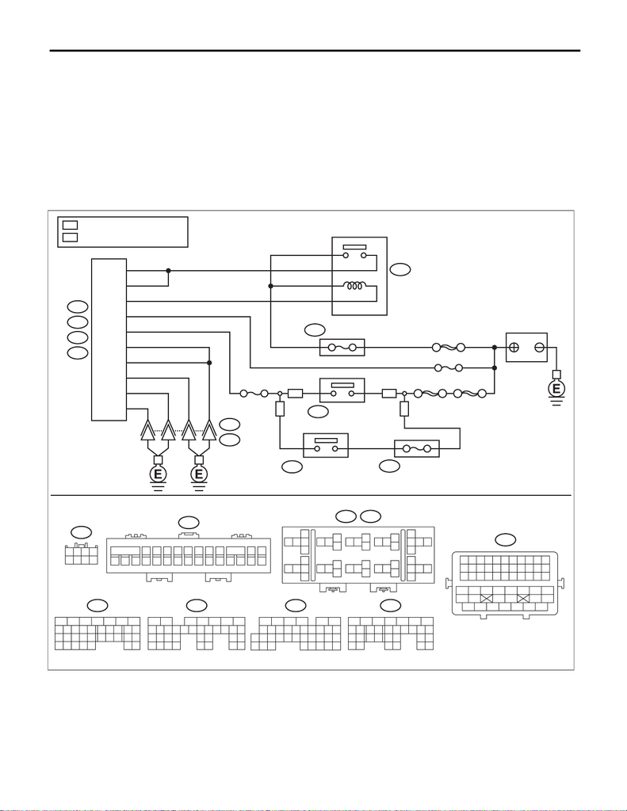

EN(STI)(diag)-77

Diagnostics for Engine Starting Failure

ENGINE (DIAGNOSTICS)

C: CHECK POWER SUPPLY AND GROUND LINE OF ENGINE CONTROL MOD-

ULE (ECM)

CAUTION:

After servicing or replacing faulty parts, perform Clear Memory Mode <Ref. to EN(STI)(diag)-59, OP-

ERATION, Clear Memory Mode.>, and Inspection Mode <Ref. to EN(STI)(diag)-43, PROCEDURE, In-

spection Mode.>.

WIRING DIAGRAM:

• Engine Electrical System ENGINE TYPE EJ (WITHOUT PUSH BUTTON START) <Ref. to WI-198, EN-

GINE TYPE EJ (WITHOUT PUSH BUTTON START), WIRING DIAGRAM, Engine Electrical System.>

• Engine Electrical System ENGINE TYPE EJ (WITH PUSH BUTTON START) <Ref. to WI-218, ENGINE

TYPE EJ (WITH PUSH BUTTON START), WIRING DIAGRAM, Engine Electrical System.>

34

40

WP

OP

WP

OP

B72

B550

216

B550

1024

B220

11

12

10

13

B134A:

B135B:

B136C:

B137D:

A3

A6

D1

D3

A4

36

35

E2

B21

C30

C2

B13

D7

C1

B220 B225

10 11

12

13

14 15

16

18

19 21 22

20

17

24

5

3

17

9

8

6

32 33

34

35

28262423

25

27

29

30

31

36 37

38

40

41 43 44

42

39

567

8

21

9

43

10

2422 23 25

11 12 13 14 15

26 27

28

16 17 18 19

20 21

29 30 31 32 33 34 35

B135B:

567

8

21

9

43

10

22 23

11 12 13 14 15

24 25

26

16 17

18 19 20 21

27 28 29 30 31

B137D:

1610 11 12 13 14 15

25

24

30

987

17 18 19 20

28

21 22

23

29 3231

1234

56

2726

33 34 35

B136C:

56 7

8

21

9

43

10

2422 23 25

11 12 13 14 15

26 27

28

16 17

18 19 20 21

33 3429

3230 31

B134A:

B21

123456789

10 11

12 13 14 15 16 17 18 19 20

21 22

34 35

42 43

36 37 38 39

48 49 50 51 52 53 54

40 41

44 45 46 47

14

B225

36 37

EN-10853

WP

OP

B72

7856

3412

101

242322 272625212019

5

14

13

18

432

17

7

16

698

15

11 12

B550

SBF-7

SBF-6

ECM

: WITHOUT PUSH BUTTON START

: WITH PUSH BUTTON START

IG RELAY 1

(PUSH BUTTON

START)

BATTERY

MAIN

RELAY

FUSE

HOLDER

FUSE

HOLDER

M/B No. 13

F/B No. 12

IGNITION

SWITCH

MAIN SBF

[figure not shown]

EN(STI)(diag)-78

Diagnostics for Engine Starting Failure

ENGINE (DIAGNOSTICS)

Step Check Yes No

1 CHECK MAIN RELAY.

1) Turn the ignition switch to OFF.

2) Remove the main relay.

3) Connect the battery to main relay terminals

No. 12 and No. 13.

4) Measure the resistance between main relay

terminals.

Terminals

No. 10 — No. 11:

Is the resistance less than 1 Ω? Go to step 2. Replace the main

relay. <Ref. to

FU(STI)-57, Main

Relay.>

2 CHECK GROUND CIRCUIT FOR ECM.

1) Disconnect the connector from ECM.

2) Measure the resistance of harness between

ECM connector and chassis ground.

Connector & terminal

(B134) No. 3 — Chassis ground:

(B134) No. 4 — Chassis ground:

(B134) No. 6 — Chassis ground:

(B137) No. 1 — Chassis ground:

(B137) No. 3 — Chassis ground:

Is the resistance less than 5 Ω? Go to step 3. Repair the harness

and connector.

NOTE:

In this case, repair

the following item:

• Open circuit of

harness between

ECM connector

and engine ground

• Poor contact of

coupling connector

3 CHECK INPUT VOLTAGE OF ECM.

1) Turn the ignition switch to ON.

2) Measure the voltage between ECM connec-

tor and chassis ground.

Connector & terminal

(B136) No. 2 (+) — Chassis ground (–):

(B136) No. 30 (+) — Chassis ground (–):

Is the voltage 10 V or more? Go to step 4. Repair the open or

ground short circuit

of harness of

power supply cir-

cuit.

4 CHECK INPUT VOLTAGE OF MAIN RELAY.

Measure the voltage between main relay con-

nector and chassis ground.

Connector & terminal

(B220) No. 11 (+) — Chassis ground (–):

(B220) No. 12 (+) — Chassis ground (–):

Is the voltage 10 V or more? Go to step 5. Repair the open or

ground short circuit

of harness of

power supply cir-

cuit.

5 CHECK INPUT VOLTAGE OF ECM.

1) Turn the ignition switch to OFF.

2) Install the main relay.

3) Turn the ignition switch to ON.

4) Measure the voltage between ECM connec-

tor and chassis ground.

Connector & terminal

(B135) No. 13 (+) — Chassis ground (–):

Is the voltage 10 V or more? Go to step 6. Repair the open or

ground short circuit

of harness

between ECM con-

nector and main

relay connector.

6 CHECK INPUT VOLTAGE OF ECM.

1) Turn the ignition switch to OFF.

2) Connect the connector to ECM.

3) Turn the ignition switch to ON.

4) Measure the voltage between ECM connec-

tor and chassis ground.

Connector & terminal

(B136) No. 1 (+) — Chassis ground (–):

(B137) No. 7 (+) — Chassis ground (–):

Is the voltage 10 V or more? Check ignition con-

trol system. <Ref.

to EN(STI)(diag)-

79, IGNITION

CONTROL SYS-

TEM, Diagnostics

for Engine Starting

Failure.>

Repair the harness

and connector.

NOTE:

In this case, repair

the following item:

• Open circuit in

harness between

ECM connector

and main relay

connector

• Poor contact of

main relay connec-

tor

• Poor contact of

ECM connector

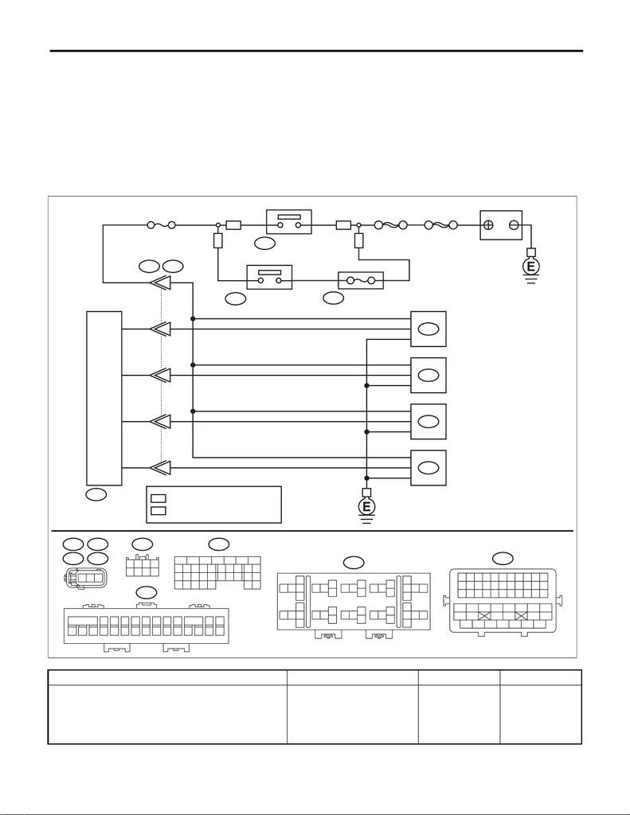

EN(STI)(diag)-79

Diagnostics for Engine Starting Failure

ENGINE (DIAGNOSTICS)

D: IGNITION CONTROL SYSTEM

CAUTION:

After servicing or replacing faulty parts, perform Clear Memory Mode <Ref. to EN(STI)(diag)-59, OP-

ERATION, Clear Memory Mode.>, and Inspection Mode <Ref. to EN(STI)(diag)-43, PROCEDURE, In-

spection Mode.>.

WIRING DIAGRAM:

• Engine Electrical System ENGINE TYPE EJ (WITHOUT PUSH BUTTON START) <Ref. to WI-198, EN-

GINE TYPE EJ (WITHOUT PUSH BUTTON START), WIRING DIAGRAM, Engine Electrical System.>

• Engine Electrical System ENGINE TYPE EJ (WITH PUSH BUTTON START) <Ref. to WI-218, ENGINE

TYPE EJ (WITH PUSH BUTTON START), WIRING DIAGRAM, Engine Electrical System.>

Step Check Yes No

1 CHECK SPARK PLUG CONDITION.

1) Remove the spark plug. <Ref. to IG(STI)-4,

REMOVAL, Spark Plug.>

2) Check the spark plug condition. <Ref. to

IG(STI)-5, INSPECTION, Spark Plug.>

Is the spark plug condition nor-

mal?

Go to step 2. Replace the spark

plug. <Ref. to

IG(STI)-4, Spark

Plug.>

WP

OP

B72

7856

3412

E32E31

E34E33

123

WP

OP

WP

OP

B72

B550

1024

14

B225

36 37

10

31

20

9

E2B21

49

2

1

3

E31

B134

21

22

31

B225

10 11

12

13

14 15

16

18

19 21 22

20

17

24

5

3

17

9

8

6

32 33

34

35

28262423

25

27

29

30

31

36 37

38

40

41 43 44

42

39

B21

123456789

10 11

12 13 14 15 16 17 18 19 20

21 22

34 35

42 43

36 37 38 39

48 49 50 51 52 53 54

40 41

44 45 46 47

B134

8

5

6

10 11 12 13 14 15

72134

16

30

19 20 22

28 29

9

17

18 2521 23 24

3231

26 27

33 34

EN-10854

2

1

3

E32

2

1

3

E33

2

1

3

E34

32

101

242322 272625212019

5

14

13

18

432

17

7

16

698

15

11 12

B550

SBF-6

ECM

BATTERY

IGNITION COIL No. 4

IGNITION COIL No. 3

IGNITION COIL No. 2

IGNITION COIL No. 1

IG RELAY 1

(PUSH BUTTON

START)

FUSE

HOLDER

F/B No. 12

IGNITION SWITCH

MAIN SBF

: WITHOUT PUSH BUTTON START

: WITH PUSH BUTTON START

[figure not shown]

EN(STI)(diag)-80

Diagnostics for Engine Starting Failure

ENGINE (DIAGNOSTICS)

2 CHECK IGNITION SYSTEM FOR SPARKS.

1) Connect the spark plug to ignition coil.

2) Release the fuel pressure. <Ref. to FU(STI)-

64, RELEASING OF FUEL PRESSURE, PRO-

CEDURE, Fuel.>

3) Contact the spark plug thread portion to

engine.

4) While opening the throttle valve fully, crank

the engine to check that spark occurs at each

cylinder.

Does spark occur at each cylin-

der?

Check fuel pump

system. <Ref. to

EN(STI)(diag)-81,

FUEL PUMP CIR-

CUIT, Diagnostics

for Engine Starting

Failure.>

Go to step 3.

3 CHECK IGNITION COIL POWER SUPPLY

CIRCUIT.

1) Turn the ignition switch to OFF.

2) Disconnect the connector from ignition coil.

3) Turn the ignition switch to ON.

4) Measure the power supply voltage between

ignition coil connector and engine ground.

Connector & terminal

(E31) No. 3 (+) — Engine ground (–):

(E32) No. 3 (+) — Engine ground (–):

(E33) No. 3 (+) — Engine ground (–):

(E34) No. 3 (+) — Engine ground (–):

Is the voltage 10 V or more? Go to step 4. Repair the harness

and connector.

NOTE:

In this case, repair

the following item:

• Open circuit or

short circuit to

ground in power

supply circuit

• Poor contact of

coupling connector

• Blown out of fuse

4 CHECK HARNESS OF IGNITION COIL

GROUND CIRCUIT.

1) Turn the ignition switch to OFF.

2) Measure the resistance between ignition

coil connector and engine ground.

Connector & terminal

(E31) No. 2 — Engine ground:

(E32) No. 2 — Engine ground:

(E33) No. 2 — Engine ground:

(E34) No. 2 — Engine ground:

Is the resistance less than 1 Ω? Go to step 5. Repair the open

circuit in harness

between ignition

coil connector and

engine ground.

5 CHECK HARNESS BETWEEN ECM AND IG-

NITION COIL CONNECTOR.

1) Turn the ignition switch to OFF.

2) Disconnect the connector from ECM and

ignition coil.

3) Measure the resistance of harness between

ECM connector and ignition coil connector.

Connector & terminal

(B134) No. 21 — (E31) No. 1:

(B134) No. 22 — (E32) No. 1:

(B134) No. 31 — (E33) No. 1:

(B134) No. 32 — (E34) No. 1:

Is the resistance less than 1 Ω? Go to step 6. Repair the harness

and connector.

NOTE:

In this case, repair

the following item:

• Open circuit of

harness between

ECM connector

and the ignition coil

connector

• Poor contact of

coupling connector

6 CHECK HARNESS BETWEEN ECM AND IG-

NITION COIL CONNECTOR.

Measure the resistance of harness between

ECM connector and engine ground.

Connector & terminal

(B134) No. 21 — Engine ground:

(B134) No. 22 — Engine ground:

(B134) No. 31 — Engine ground:

(B134) No. 32 — Engine ground:

Is the resistance 1 MΩ or

more?

Go to step 7. Repair the ground

short circuit of har-

ness between

ECM connector

and ignition coil

connector.

7 CHECK FOR POOR CONTACT.

Check for poor contact of ECM connector.

Is there poor contact of ECM

connector?

Repair the poor

contact of ECM

connector.

Replace the igni-

tion coil. <Ref. to

IG(STI)-7, Ignition

Coil.>

Step Check Yes No

[figure not shown]

EN(STI)(diag)-81

Diagnostics for Engine Starting Failure

ENGINE (DIAGNOSTICS)

E: FUEL PUMP CIRCUIT

CAUTION:

After servicing or replacing faulty parts, perform Clear Memory Mode <Ref. to EN(STI)(diag)-59, OP-

ERATION, Clear Memory Mode.>, and Inspection Mode <Ref. to EN(STI)(diag)-43, PROCEDURE, In-

spection Mode.>.

Step Check Yes No

1 CHECK OPERATING SOUND OF FUEL

PUMP.

Make sure that the fuel pump operates for two

seconds when turning the ignition switch to ON.

NOTE:

Fuel pump operation can be executed using the

Subaru Select Monitor.

For detailed procedures, refer to “SYSTEM OP-

ERATION CHECK MODE”. <Ref. to

EN(STI)(diag)-60, System Operation Check

Mode.>

Does the fuel pump emit oper-

ating sound?

Check the fuel

injector circuit.

<Ref. to

EN(STI)(diag)-82,

FUEL INJECTOR

CIRCUIT, Diag-

nostics for Engine

Starting Failure.>

Display the DTC.

<Ref. to

EN(STI)(diag)-42,

OPERATION,

Read Diagnostic

Trouble Code

(DTC).>

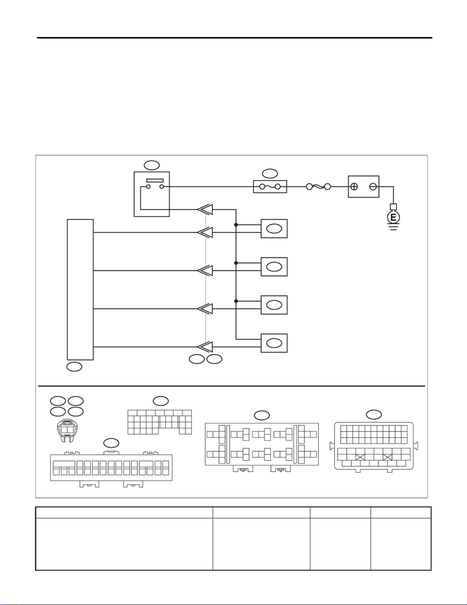

EN(STI)(diag)-82

Diagnostics for Engine Starting Failure

ENGINE (DIAGNOSTICS)

F: FUEL INJECTOR CIRCUIT

CAUTION:

• Check or repair only faulty parts.

• After servicing or replacing faulty parts, perform Clear Memory Mode <Ref. to EN(STI)(diag)-59,

OPERATION, Clear Memory Mode.>, and Inspection Mode <Ref. to EN(STI)(diag)-43, PROCEDURE,

Inspection Mode.>.

WIRING DIAGRAM:

• Engine Electrical System ENGINE TYPE EJ (WITHOUT PUSH BUTTON START) <Ref. to WI-198, EN-

GINE TYPE EJ (WITHOUT PUSH BUTTON START), WIRING DIAGRAM, Engine Electrical System.>

• Engine Electrical System ENGINE TYPE EJ (WITH PUSH BUTTON START) <Ref. to WI-218, ENGINE

TYPE EJ (WITH PUSH BUTTON START), WIRING DIAGRAM, Engine Electrical System.>

Step Check Yes No

1 CHECK OPERATION OF EACH FUEL INJEC-

TOR.

While cranking the engine, check each fuel

injector emits operating sound. Use a sound

scope or attach a screwdriver to the injector for

this check.

Does the fuel injector emit

operating sound?

Check the fuel

pressure. <Ref. to

ME(STI)-25,

INSPECTION,

Fuel Pressure.>

Go to step 2.

10

B220

11

B550

216

51

52

53

54

E2

B21

48

2

1

E5

B134

10

11

12

B220

10 11

12

13

14 15

16

18

19 21 22

20

17

24

5

3

17

9

8

6

32 33

34

35

28262423

25

27

29

30

31

36 37

38

40

41 43 44

42

39

B21

123456789

10 11

12 13 14 15 16 17 18 19 20

21 22

34 35

42 43

36 37 38 39

48 49 50 51 52 53 54

40 41

44 45 46 47

B134

8

5

6

10 11 12 13 14 15

72134

16

30

19 20 22

28 29

9

17

18 2521 23 24

3231

26 27

33 34

EN-10855

2

1

E16

2

1

E6

2

1

E17

13

E5

E6

E16

E17

21

101

242322 272625212019

5

14

13

18

432

17

7

16

698

15

11 12

B550

SBF-7

ECM

FUEL INJECTOR No. 4

FUEL INJECTOR No. 3

FUEL INJECTOR No. 2

FUEL INJECTOR No. 1

BATTERY

FUSE HOLDER

MAIN RELAY

[figure not shown]

EN(STI)(diag)-83

Diagnostics for Engine Starting Failure

ENGINE (DIAGNOSTICS)

2 CHECK POWER SUPPLY TO EACH FUEL IN-

JECTOR.

1) Turn the ignition switch to OFF.

2) Disconnect the connector from fuel injector.

3) Turn the ignition switch to ON.

4) Measure the power supply voltage between

fuel injector connector and the engine ground.

Connector & terminal

#1 (E5) No. 1 (+) — Engine ground (–):

#2 (E16) No. 1 (+) — Engine ground (–):

#3 (E6) No. 1 (+) — Engine ground (–):

#4 (E17) No. 1 (+) — Engine ground (–):

Is the voltage 10 V or more? Go to step 3. Repair the harness

and connector.

NOTE:

In this case, repair

the following item:

• Open circuit in

harness between

main relay connec-

tor and fuel injector

connector

• Poor contact of

main relay connec-

tor

• Poor contact of

coupling connector

3 CHECK HARNESS BETWEEN ECM AND

FUEL INJECTOR CONNECTOR.

1) Turn the ignition switch to OFF.

2) Disconnect the connector from ECM.

3) Measure the resistance of harness between

ECM connector and fuel injector connector.

Connector & terminal

#1 (B134) No. 10 — (E5) No. 2:

#2 (B134) No. 11 — (E16) No. 2:

#3 (B134) No. 12 — (E6) No. 2:

#4 (B134) No. 13 — (E17) No. 2:

Is the resistance less than 1 Ω? Go to step 4. Repair the harness

and connector.

NOTE:

In this case, repair

the following item:

• Open circuit in

harness between

ECM connector

and fuel injector

connector

• Poor contact of

coupling connector

4 CHECK HARNESS BETWEEN ECM AND

FUEL INJECTOR CONNECTOR.

Measure the resistance of harness between

ECM connector and chassis ground.

Connector & terminal

#1 (B134) No. 10 — Chassis ground:

#2 (B134) No. 11 — Chassis ground:

#3 (B134) No. 12 — Chassis ground:

#4 (B134) No. 13 — Chassis ground:

Is the resistance 1 MΩ or

more?

Go to step 5. Repair the short

circuit to ground in

harness between

ECM connector

and fuel injector

connector.

5 CHECK EACH FUEL INJECTOR.

Measure the resistance between each fuel

injector terminals.

Terminals

No. 1 — No. 2:

Is the resistance 5 — 20 Ω? Go to step 6. Replace the faulty

fuel injector. <Ref.

to FU(STI)-43,

Fuel Injector.>

6 CHECK FOR POOR CONTACT.

Check for poor contact of ECM connector.

Is there poor contact of ECM

connector?

Repair the poor

contact of ECM

connector.

Inspection using

“General Diagnos-

tic Table”. <Ref. to

EN(STI)(diag)-

429, INSPEC-

TION, General

Diagnostic Table.>

Step Check Yes No